# Homework3_Nield

Emily Nield

February 23, 2015

## Setup

First, let’s do some preliminary work: setting the workspace, loading libraries and loading data.

```r
setwd('C:/Users/Emily/Documents/enield/homework3/')
```

```r
library(ggplot2)
library(dplyr)
library(tidyr)
library(magrittr) # for the %$% notation I'll use later.
```

```r
precip <- read.csv('data/precip.csv')
rwi <- read.csv('data/rwi.csv')
gd <- read.csv('data/GalapagosData.csv')

summary(rwi)
```

```
##       year           rwi            samp.depth
##  Min.   :-136   Min.   :-0.0330   Min.   : 1.00
##  1st Qu.: 399   1st Qu.: 0.6610   1st Qu.: 8.00
##  Median : 934   Median : 0.9660   Median :13.00
##  Mean   : 934   Mean   : 0.9765   Mean   :16.35
##  3rd Qu.:1469   3rd Qu.: 1.2590   3rd Qu.:23.00
##  Max.   :2004   Max.   : 3.0640   Max.   :66.00
```

```r
summary(precip)
```

```
##       year           Jan             Feb              Mar
##  Min.   :1895   Min.   :0.020   Min.   :0.0300   Min.   :0.0200
##  1st Qu.:1925   1st Qu.:0.335   1st Qu.:0.3500   1st Qu.:0.4475
##  Median :1954   Median :0.710   Median :0.6800   Median :0.6950
##  Mean   :1954   Mean   :0.837   Mean   :0.8341   Mean   :0.8645
##  3rd Qu.:1984   3rd Qu.:1.198   3rd Qu.:1.1575   3rd Qu.:1.2425
##  Max.   :2014   Max.   :2.790   Max.   :3.3100   Max.   :3.1800
##       Apr              May              Jun              Jul
##  Min.   :0.0100   Min.   :0.0000   Min.   :0.0000   Min.   :0.860
##  1st Qu.:0.2275   1st Qu.:0.1500   1st Qu.:0.2450   1st Qu.:1.875
##  Median :0.5000   Median :0.3600   Median :0.6050   Median :2.565
##  Mean   :0.6528   Mean   :0.5436   Mean   :0.7132   Mean   :2.660
##  3rd Qu.:0.8725   3rd Qu.:0.8025   3rd Qu.:1.0925   3rd Qu.:3.290
##  Max.   :2.9800   Max.   :3.0100   Max.   :2.5000   Max.   :5.960
##       Aug             Sep             Oct              Nov
##  Min.   :0.600   Min.   :0.030   Min.   :0.0000   Min.   :0.0000
##  1st Qu.:2.252   1st Qu.:1.058   1st Qu.:0.3875   1st Qu.:0.2050
##  Median :2.810   Median :1.775   Median :0.8900   Median :0.5900
##  Mean   :2.856   Mean   :1.821   Mean   :1.1472   Mean   :0.7254
##  3rd Qu.:3.393   3rd Qu.:2.433   3rd Qu.:1.6525   3rd Qu.:0.9700
##  Max.   :5.820   Max.   :5.110   Max.   :5.1800   Max.   :4.0300
##       Dec
##  Min.   :-9.9900
##  1st Qu.: 0.3675
##  Median : 0.7800
##  Mean   : 0.9164
##  3rd Qu.: 1.4600
##  Max.   : 3.9200
```

## Data Tidying

I want to create a data.frame that has columns of:

year, month, precip. Remember, the precip does not come in that format. Instead it looks like this:

```r
head(precip)
```

```
##   year  Jan  Feb  Mar  Apr  May  Jun  Jul  Aug  Sep  Oct  Nov  Dec
## 1 1895 1.08 0.78 0.11 0.10 1.12 0.63 4.07 3.74 1.25 0.81 1.73 0.23
## 2 1896 0.25 0.20 0.20 0.15 0.01 0.71 3.25 1.80 2.37 4.28 0.10 0.22
## 3 1897 1.29 0.20 1.15 0.69 1.09 0.56 2.57 2.57 4.77 1.99 0.08 0.69
## 4 1898 1.13 0.35 0.98 0.88 0.31 1.89 3.49 2.87 0.66 0.05 0.93 1.19
## 5 1899 0.22 0.21 0.43 0.55 0.03 0.78 3.91 1.43 1.17 0.47 0.50 0.24
## 6 1900 0.69 0.50 1.08 0.94 0.36 0.23 1.18 0.94 3.53 0.43 0.75 0.28
```

I will gather the data into one column called precip…

```r
precip.df <- precip %>% gather(key=month, value=precip, -year) %>% arrange(year, month)
head(precip.df)
```

```
##   year month precip
## 1 1895   Jan   1.08
## 2 1895   Feb   0.78
## 3 1895   Mar   0.11
## 4 1895   Apr   0.10
## 5 1895   May   1.12
## 6 1895   Jun   0.63
```

Create a new column that is the “hydologic year”, or the precipitation year that the tree growth seems to correspond to.

```r
precip.df <- precip.df %>% mutate(water_year = lead(year, 6))
head(precip.df, 20)
```

```
##    year month precip water_year
## 1  1895   Jan   1.08       1895
## 2  1895   Feb   0.78       1895
## 3  1895   Mar   0.11       1895
## 4  1895   Apr   0.10       1895
## 5  1895   May   1.12       1895
## 6  1895   Jun   0.63       1895
## 7  1895   Jul   4.07       1896
## 8  1895   Aug   3.74       1896
## 9  1895   Sep   1.25       1896
## 10 1895   Oct   0.81       1896
## 11 1895   Nov   1.73       1896
## 12 1895   Dec   0.23       1896
## 13 1896   Jan   0.25       1896
## 14 1896   Feb   0.20       1896
## 15 1896   Mar   0.20       1896
## 16 1896   Apr   0.15       1896
## 17 1896   May   0.01       1896
## 18 1896   Jun   0.71       1896
## 19 1896   Jul   3.25       1897
## 20 1896   Aug   1.80       1897
```

With this water_year column in place, we want to calculate the total precipitation each water_year. This is a group and summarize task.

```r
annual_precip <- precip.df %>% group_by(water_year) %>%
  summarize(precip=sum(precip)) %>%
  filter(water_year>1895)
# Don't forget to filter out year=1895 because it wasn't complete.
head(annual_precip)
```

```
## Source: local data frame [6 x 2]
##
##   water_year precip
## 1       1896  13.35
## 2       1897  17.00
## 3       1898  18.21
## 4       1899  11.41
## 5       1900  11.52
## 6       1901  10.43
```

Now we can merge that with the tree ring data…

```r
rwi.precip.df <- left_join(rwi, annual_precip, by=c('year'='water_year'))
tail(rwi.precip.df)
```

```
##      year    rwi samp.depth precip
## 2136 1999  1.157         60  14.93
## 2137 2000  0.591         60  15.75
## 2138 2001  0.913         60  15.48
## 2139 2002 -0.033         59   9.77
## 2140 2003  0.710         59  15.02
## 2141 2004  0.419         53  12.87
```

## Exploratory analysis

Plot a scatterplot. You should always visualize the data first.

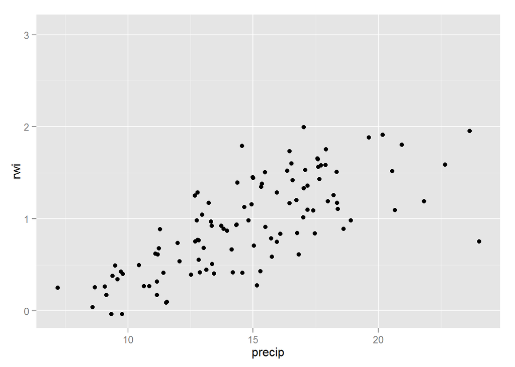

```r
ggplot(data=rwi.precip.df) + geom_point(aes(x=precip, y=rwi))
```

## Linear regression Nonetheless, we’ll fit a linear regression to the data.

```r
# Fit the model
model <- lm(rwi~precip, data=rwi.precip.df, na.action=na.exclude)
# Print out a summary
summary(model)
```

```
##
## Call:
## lm(formula = rwi ~ precip, data = rwi.precip.df, na.action = na.exclude)
##
## Residuals:
##      Min       1Q   Median       3Q      Max
## -1.18958 -0.24341  0.03348  0.21877  0.87653
##
## Coefficients:
##              Estimate Std. Error t value Pr(>|t|)
## (Intercept) -0.660621   0.146582  -4.507 1.69e-05 ***
## precip       0.108460   0.009682  11.202  < 2e-16 ***
## ---
## Signif. codes:  0 '***' 0.001 '**' 0.01 '*' 0.05 '.' 0.1 ' ' 1
##
## Residual standard error: 0.3477 on 107 degrees of freedom
##   (2032 observations deleted due to missingness)
## Multiple R-squared:  0.5397, Adjusted R-squared:  0.5354
## F-statistic: 125.5 on 1 and 107 DF,  p-value: < 2.2e-16
```

## Regression Diagnostics

Regression diagnostic plots

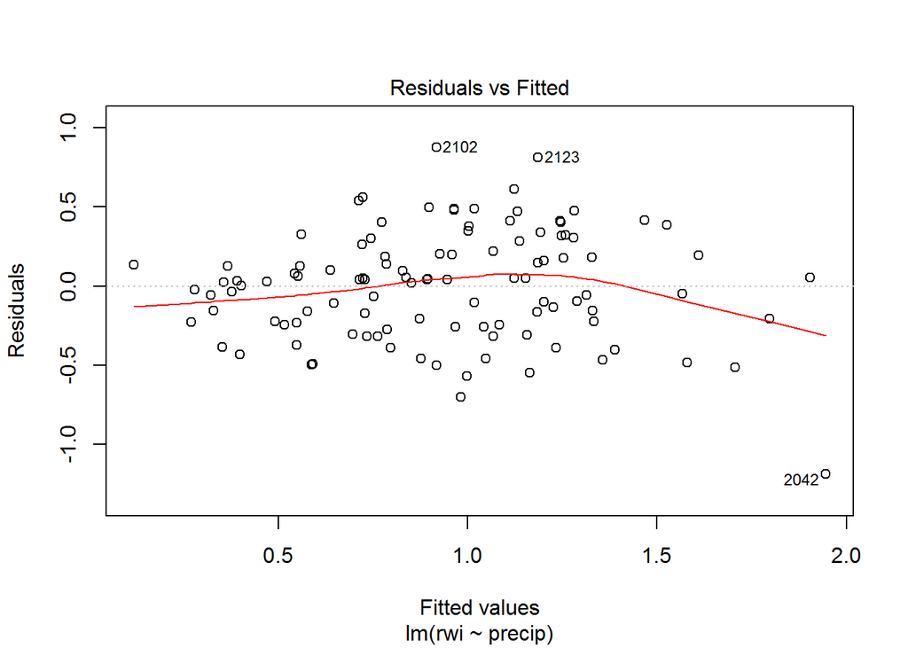

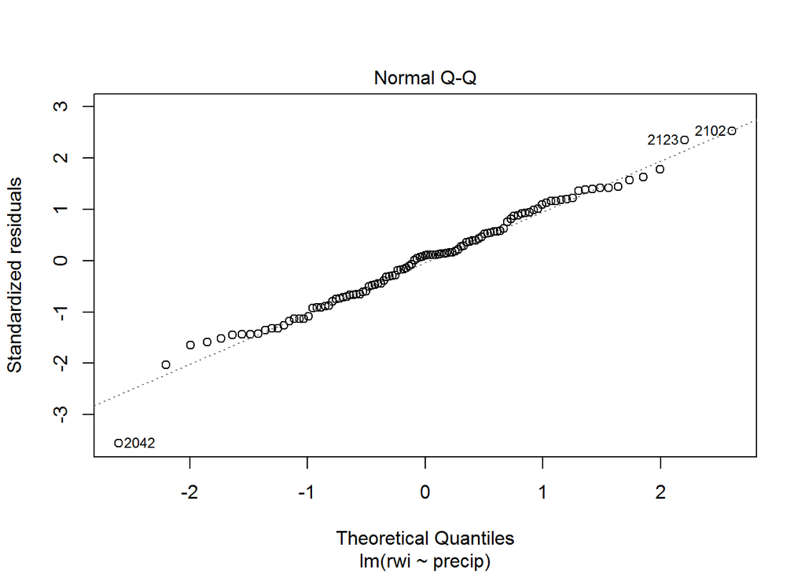

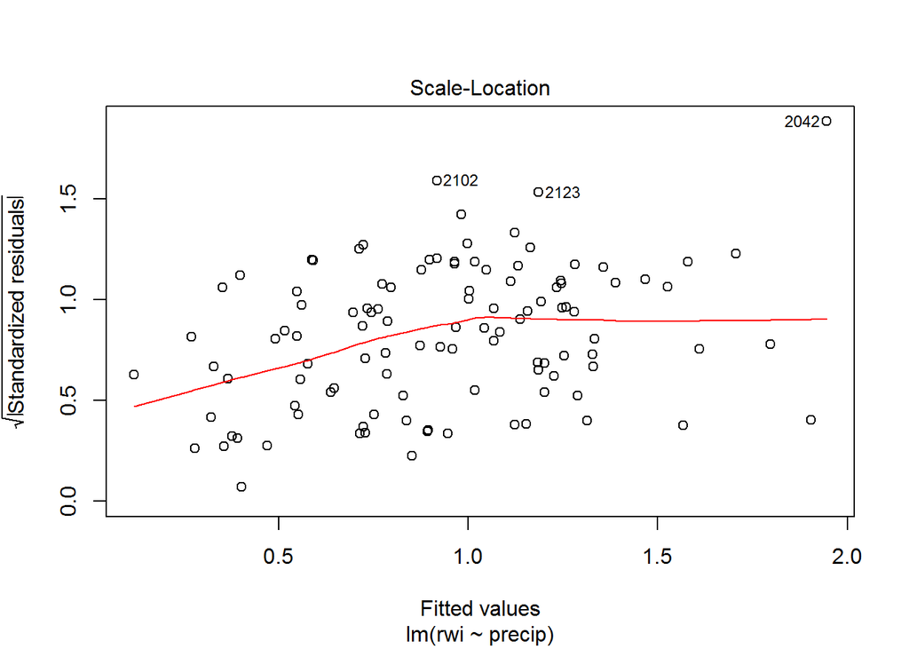

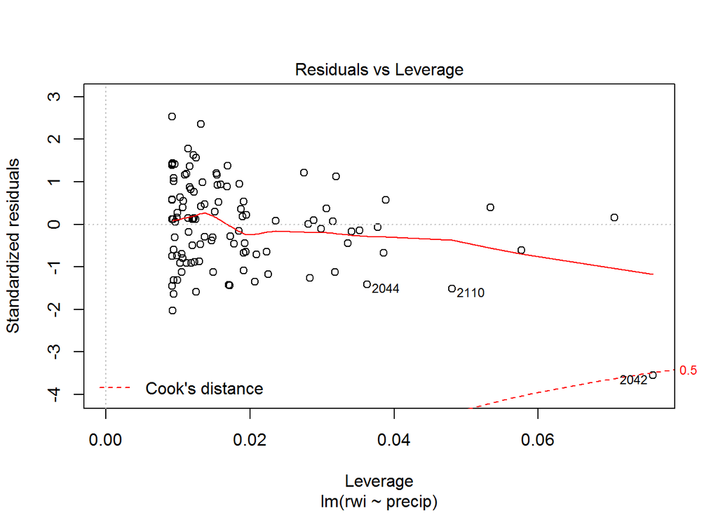

```r
plot(model) # You can then step through each plot, Hit <Return> to see the next plot
```

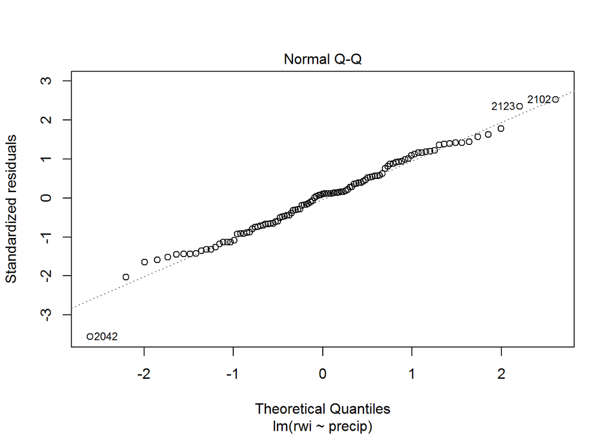

```r
# Or you can see one plot at a time, e.g.
plot(model, which=2)
```

## Homework Question 1

Homework: For the first three plots, describe wich assumptions they help to visually evaluate.

On the first regression plot the data follows a curve that is in the shape of a parabola that opens downwards. This suggests a non-linearity in our data. This shape can be explained in the following diagram:

[figure not shown]

We assumed that there was a linear relationship between our two variables, as shown in blue in the above diagram, but in reality there is most likely a logarithmic relationship between them. This would cause the residuals to be negative at the end of the curve and positive in the middle. This would explain the curve in the first regression plot.

The second regression plot is a quartile plot and it is used to test the assumption that the residuals are normally distributed. If the residuals were normally distributed than there would be a straight line. The line in this graph is mildly sinuous so the residuals are not normally distributed perfectlly but it is close enough.

The third residual plot is used to test the assumption that the variance is constant. If the variance is constant than there would be a straight horizontal line on this plot but the line is kinked so this assumption is not true for our example.

## Homework Question 2

Homework: These data are time series data. In general, data are correlated in time, and this would be a problem for simple linear regression. Plot the regression residuals vs time, and visually assess whether there is evidence of temporal (serial) correlation.

Add a new coloumn to the data set for residuals in order to plot year against the residuals.

```r
# Add the residual column
rwi.precip.df $resid <- residuals (model)
# Print out a summary
head(rwi.precip.df)
```

```
##   year   rwi samp.depth precip resid
## 1 -136 0.568          1     NA    NA
## 2 -135 1.024          1     NA    NA
## 3 -134 0.900          1     NA    NA
## 4 -133 0.330          1     NA    NA
## 5 -132 0.382          1     NA    NA
## 6 -131 0.625          1     NA    NA
```

Plot the data

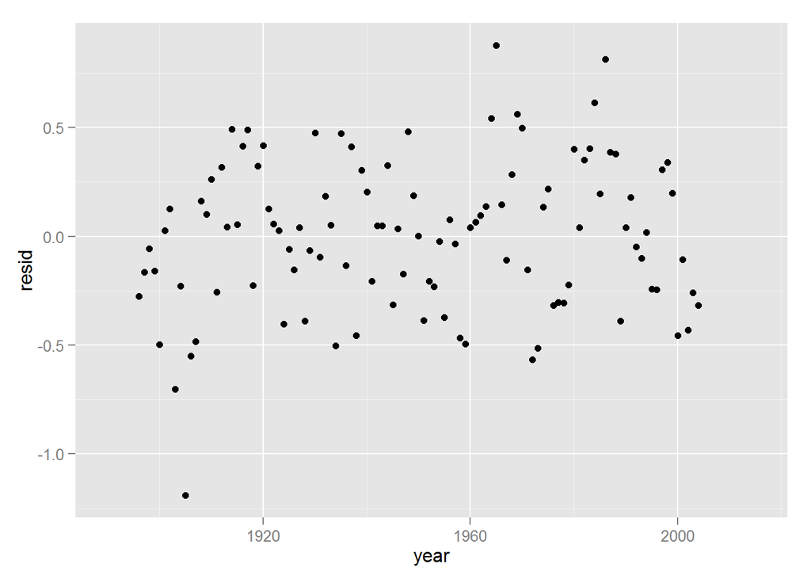

```r
ggplot(data=rwi.precip.df) + geom_point(aes(x=year, y=resid)) + scale_x_continuous(limits = c(1890, 2015))
```

## Homework Question 3

Homework: In the data folder is the dataset GalapagosData.txt. The species data represents the number of species recorded from each of the Galapagos islands. A fundamental ‘law’ of island biogeography is that species diversity tends to follow a power law relationship with island area, i.e. $\mbox{species} = \alpha\times{\mbox{area}^\beta}$  
This is not linear, but it suggests that the following regression might make sense: $\log(\mbox{species}) = a + \beta \times log(\mbox{area})$ $a$ is not quite $\alpha$, rather $a=\log(\alpha)$.  
Fit this regression, and present a brief write-up that a) describes the results in words, and b) summarizes your conclusions from diagnostic model checking.

Plot the data on a log-log scale

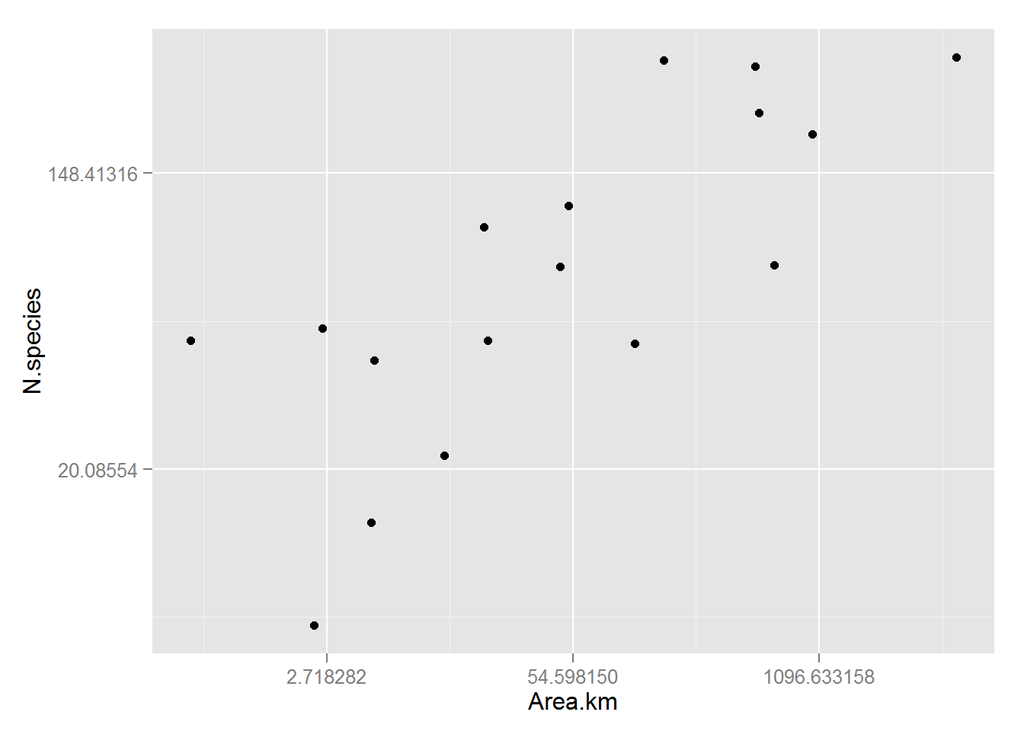

```r
ggplot(data=gd) + geom_point(aes(x=Area.km, y=N.species)) + scale_y_continuous(trans = "log") + scale_x_continuous(trans = "log")
```

```r
model2 <- lm(Log_N_Species~Log_Area_km, data=gd)

summary(model2)
```

```
##
## Call:
## lm(formula = Log_N_Species ~ Log_Area_km, data = gd)
##
## Residuals:
##      Min       1Q   Median       3Q      Max
## -0.59621 -0.32673  0.02621  0.25957  0.45588
##
## Coefficients:
##             Estimate Std. Error t value Pr(>|t|)
## (Intercept)  1.31980    0.14213   9.286 1.31e-07 ***
## Log_Area_km  0.33059    0.07194   4.595  0.00035 ***
## ---
## Signif. codes:  0 '***' 0.001 '**' 0.01 '*' 0.05 '.' 0.1 ' ' 1
##
## Residual standard error: 0.3204 on 15 degrees of freedom
## Multiple R-squared:  0.5847, Adjusted R-squared:  0.557
## F-statistic: 21.12 on 1 and 15 DF,  p-value: 0.0003501
```

Diagnostic Model Checking: In order to do this we need to plot the resdidual graphs.

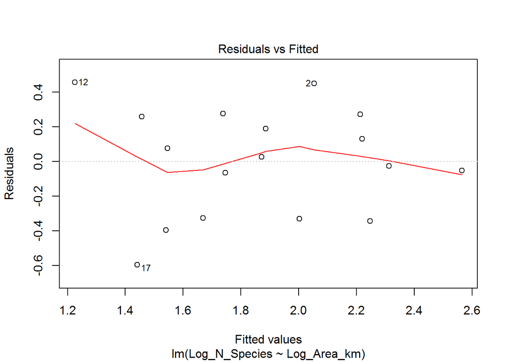

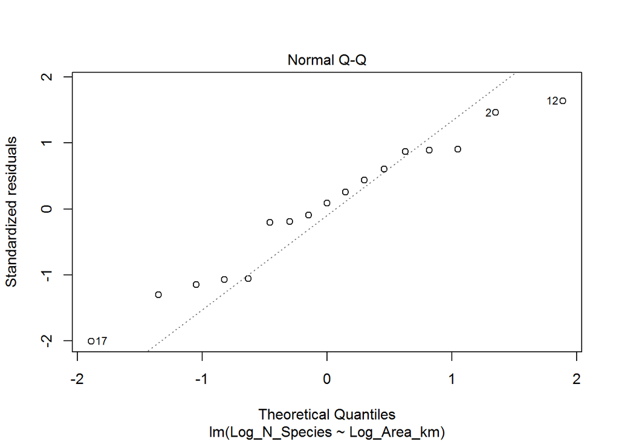

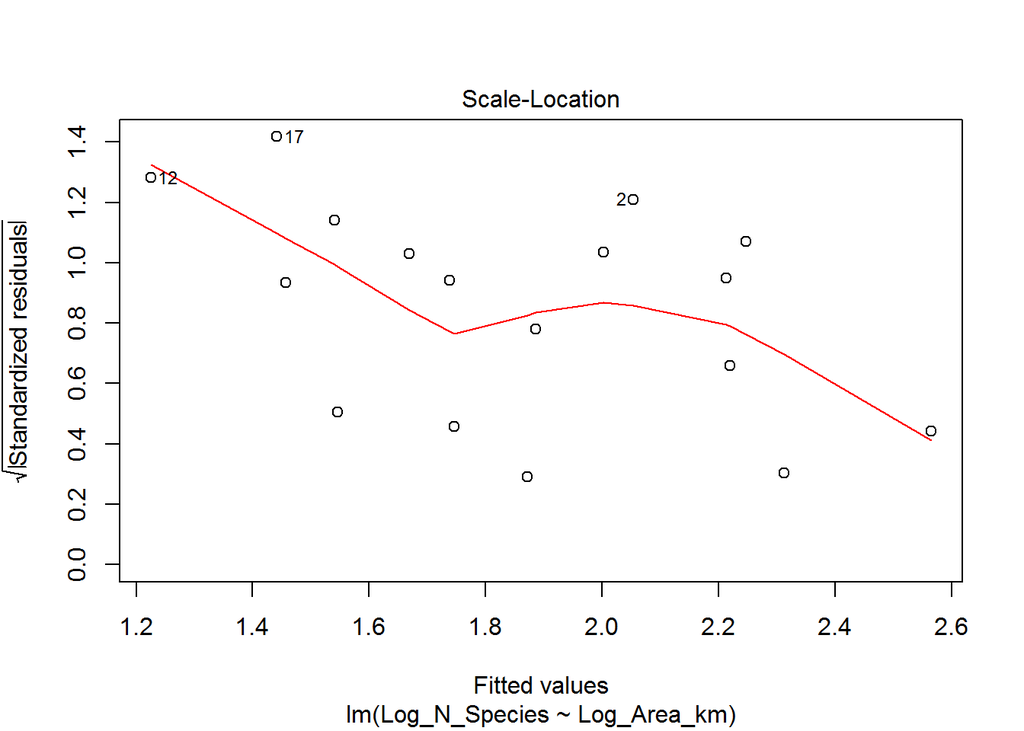

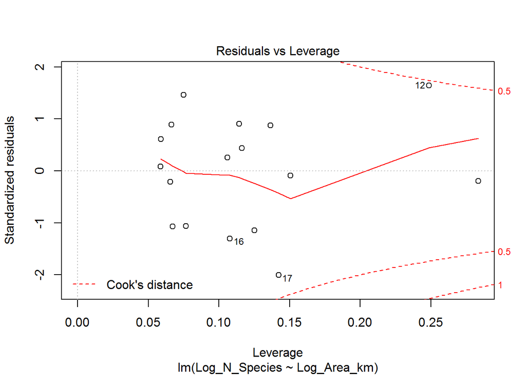

```r
plot(model2)
```

2. In order to apply a linear regression it is assumed that there is a linear relationship between the two variables. This is tested in the first residual plot. Ideally you would want a horizontal line in this plot but are line has kinks so this suggests there is a weak correlation between our variables. This is most likely due to the outliers in the data set. These outliers are the following islands: Charles, Gardner, and Culpepper. This could be a result of human occupation leading to a decrease in species that occupy an island. This is a small data set (less than 30 degrees of freedom) so in order to properly apply a linear regression one must assume that the errors around the line will have a bell curve distribution. The second residual plot assesses this assumption. The data in this plot do not fit on a straight line so this assumption is not valid.  
   Another assumption for linear regressions is that the variance is constant. This is tested in the third residual plot. If the variance is constant than there would be a straight line on this plot but the line is kinked so this assumption is not true for our example.